# challenge-notebook

This python notebook is from an assignment for the machine learning course at Bocconi University, May 2023. It marks my first attempt at creating my own machine learning model/project. The objective of this notebook was to create a predictive model that accurately predicts the prices of houses from a given dataset. The perfmance metric assigned to this task was MSE.

```python
# This Python 3 environment comes with many helpful analytics libraries installed
# It is defined by the kaggle/python Docker image: https://github.com/kaggle/docker-python
# For example, here's several helpful packages to load

import numpy as np # linear algebra
import pandas as pd # data processing, CSV file I/O (e.g. pd.read_csv)

# Input data files are available in the read-only "../input/" directory
# For example, running this (by clicking run or pressing Shift+Enter) will list all files under the input directory

import os
for dirname, _, filenames in os.walk('/kaggle/input'):
    for filename in filenames:
        print(os.path.join(dirname, filename))

# You can write up to 20GB to the current directory (/kaggle/working/) that gets preserved as output when you create a version using "Save & Run All"
# You can also write temporary files to /kaggle/temp/, but they won't be saved outside of the current session
```

```
/kaggle/input/train2/train2.csv
/kaggle/input/challengedata/sample_submission.csv
/kaggle/input/challengedata/train.csv
/kaggle/input/challengedata/test.csv
/kaggle/input/challengedata/poi.csv
/kaggle/input/challenge/test_updated.csv
```

**Name / Kaggle Username:** Omar Mukhtar

**Student ID:** 3182217

# Reading the Data:

```python
!pip install reverse_geocoder
```

[output not shown]

```python
import numpy as np
import pandas as pd
import matplotlib.pyplot as plt
import seaborn as sns
plt.style.use = ('ggplot')
pd.set_option('max_columns', 20)

train_file_path = '../input/train2/train2.csv'
train_data = pd.read_csv(train_file_path)
```

# Data Understanding

Loading in the data and understanding its shapes and features

```python
train_data.shape
```

```
(46312, 17)
```

```python
train_data.head()
```

|  | id | price | balcony | conditions | construction_year | latitude | longitude | energy_efficiency | expenses | floor | garden | n_bathrooms | elevator | total_floors | n_rooms | proximity_to_center | surface |
| --- | --- | --- | --- | --- | --- | --- | --- | --- | --- | --- | --- | --- | --- | --- | --- | --- | --- |
| 0 | 10461 | 60000 | True | Buono stato / Abitabile | 1980.0 | 41.901300 | 12.700000 | 175.00 | 30.0 | 2.0 | NaN | 1.0 | NaN | 3.0 | 1.0 | 1.00000 | 35.0 |
| 1 | 51304 | 900000 | NaN | Buono stato / Abitabile | NaN | 41.907017 | 12.481311 | NaN | NaN | 3.0 | NaN | 1.0 | 1.0 | NaN | 3.0 | 1.00000 | 131.0 |
| 2 | 33032 | 33000 | NaN | Buono stato / Abitabile | 1960.0 | 41.976500 | 12.440500 | 204.20 | 30.0 | 4.0 | NaN | 1.0 | NaN | 4.0 | 1.0 | 1.00000 | 16.0 |
| 3 | 62281 | 166000 | NaN | Ottimo / Ristrutturato | NaN | 45.484800 | 12.198200 | 175.00 | NaN | 1.0 | True | 1.0 | NaN | 1.0 | 2.0 | 0.99205 | 100.0 |
| 4 | 45681 | 410000 | True | Buono stato / Abitabile | NaN | 45.424480 | 12.328622 | 65.91 | NaN | 3.0 | NaN | 2.0 | 1.0 | NaN | 3.0 | 1.00000 | 90.0 |

```python
train_data.tail()
```

|  | id | price | balcony | conditions | construction_year | latitude | longitude | energy_efficiency | expenses | floor | garden | n_bathrooms | elevator | total_floors | n_rooms | proximity_to_center | surface |
| --- | --- | --- | --- | --- | --- | --- | --- | --- | --- | --- | --- | --- | --- | --- | --- | --- | --- |
| 46307 | 33085 | 329999 | True | Buono stato / Abitabile | 1929.0 | 41.923500 | 12.446100 | 175.0 | 35.0 | 3.0 | NaN | 1.0 | NaN | 4.0 | 3.0 | 1.0 | 88.0 |
| 46308 | 17403 | 599000 | True | Da ristrutturare | 1920.0 | 41.916743 | 12.454925 | NaN | 170.0 | 6.0 | NaN | 2.0 | 1.0 | NaN | 5.0 | 1.0 | 189.0 |
| 46309 | 33332 | 549000 | True | Buono stato / Abitabile | NaN | 45.454701 | 9.242711 | NaN | NaN | NaN | NaN | 2.0 | 1.0 | NaN | 3.0 | 1.0 | 140.0 |
| 46310 | 63367 | 189000 | True | Buono stato / Abitabile | 1965.0 | 45.445605 | 9.245942 | NaN | 150.0 | -1.0 | True | 1.0 | 1.0 | NaN | 3.0 | 1.0 | 70.0 |
| 46311 | 27322 | 355000 | True | Ottimo / Ristrutturato | 1970.0 | 41.877000 | 12.431400 | 175.0 | 100.0 | 1.0 | NaN | 1.0 | 1.0 | 5.0 | 4.0 | 1.0 | 101.0 |

```python
train_data.describe()
```

|  | id | price | construction_year | latitude | longitude | energy_efficiency | expenses | floor | n_bathrooms | elevator | total_floors | n_rooms | proximity_to_center | surface |
| --- | --- | --- | --- | --- | --- | --- | --- | --- | --- | --- | --- | --- | --- | --- |
| count | 46312.000000 | 4.631200e+04 | 32366.000000 | 46299.000000 | 46299.000000 | 2.640900e+04 | 30158.000000 | 44281.000000 | 43896.000000 | 28869.000000 | 27963.000000 | 45959.000000 | 46299.000000 | 45869.000000 |
| mean | 32960.756132 | 5.031879e+05 | 1958.032874 | 43.534743 | 11.451295 | 5.091382e+03 | 195.285132 | 2.033333 | 1.559140 | 0.952510 | 5.724207 | 3.284166 | 0.994756 | 114.866620 |
| std | 19090.178152 | 1.106504e+06 | 72.021035 | 1.789416 | 1.502453 | 7.600521e+05 | 4035.008418 | 2.175668 | 0.769869 | 0.212689 | 191.115233 | 1.329654 | 0.030093 | 88.650549 |
| min | 0.000000 | 1.540000e+02 | 1000.000000 | 41.690300 | 9.060775 | 1.000000e-02 | 0.000000 | -5.000000 | 1.000000 | 0.000000 | 1.000000 | 1.000000 | 0.588014 | 0.000000 |
| 25% | 16466.500000 | 1.990000e+05 | 1950.000000 | 41.882400 | 9.221300 | 1.590000e+02 | 40.000000 | 1.000000 | 1.000000 | 1.000000 | 3.000000 | 2.000000 | 1.000000 | 68.000000 |
| 50% | 32906.500000 | 3.150000e+05 | 1967.000000 | 41.960604 | 12.361864 | 1.750000e+02 | 80.000000 | 2.000000 | 1.000000 | 1.000000 | 4.000000 | 3.000000 | 1.000000 | 91.000000 |
| 75% | 49489.250000 | 5.150000e+05 | 1987.000000 | 45.465800 | 12.487604 | 1.750000e+02 | 150.000000 | 3.000000 | 2.000000 | 1.000000 | 6.000000 | 4.000000 | 1.000000 | 130.000000 |
| max | 66159.000000 | 7.200000e+07 | 2500.000000 | 45.561298 | 12.854100 | 1.234570e+08 | 346000.000000 | 56.000000 | 9.000000 | 1.000000 | 31960.000000 | 9.000000 | 1.000000 | 990.000000 |

```python
train_data.columns
```

```
Index(['id', 'price', 'balcony', 'conditions', 'construction_year', 'latitude',
       'longitude', 'energy_efficiency', 'expenses', 'floor', 'garden',
       'n_bathrooms', 'elevator', 'total_floors', 'n_rooms',
       'proximity_to_center', 'surface'],
      dtype='object')
```

```python
train_data.dtypes
```

```
id                       int64
price                    int64
balcony                 object
conditions              object
construction_year      float64
latitude               float64
longitude              float64
energy_efficiency      float64
expenses               float64
floor                  float64
garden                  object
n_bathrooms            float64
elevator               float64
total_floors           float64
n_rooms                float64
proximity_to_center    float64
surface                float64
dtype: object
```

```python
train_data.info()
```

```
<class 'pandas.core.frame.DataFrame'>
RangeIndex: 46312 entries, 0 to 46311
Data columns (total 17 columns):
 #   Column               Non-Null Count  Dtype
---  ------               --------------  -----
 0   id                   46312 non-null  int64
 1   price                46312 non-null  int64
 2   balcony              30869 non-null  object
 3   conditions           45083 non-null  object
 4   construction_year    32366 non-null  float64
 5   latitude             46299 non-null  float64
 6   longitude            46299 non-null  float64
 7   energy_efficiency    26409 non-null  float64
 8   expenses             30158 non-null  float64
 9   floor                44281 non-null  float64
 10  garden               14783 non-null  object
 11  n_bathrooms          43896 non-null  float64
 12  elevator             28869 non-null  float64
 13  total_floors         27963 non-null  float64
 14  n_rooms              45959 non-null  float64
 15  proximity_to_center  46299 non-null  float64
 16  surface              45869 non-null  float64
dtypes: float64(12), int64(2), object(3)
memory usage: 6.0+ MB
```

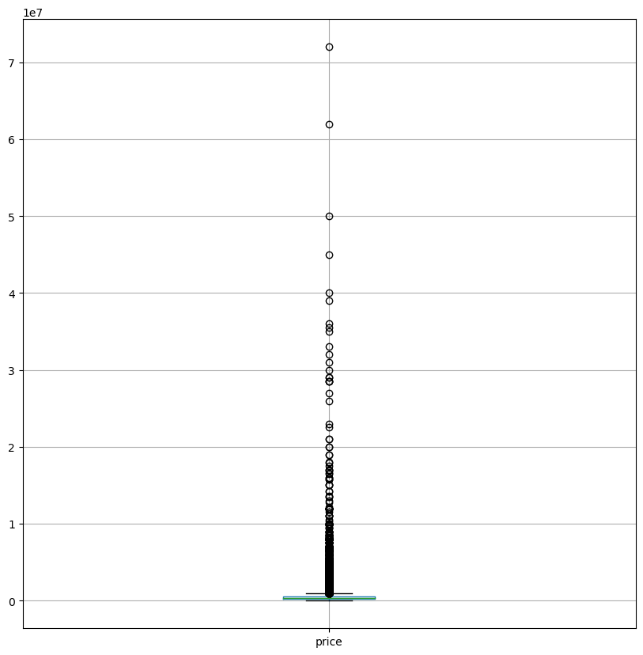

```python
# boxplot for price
train_data.boxplot(['price'], figsize = (10,10))
```

Clearly prices are concentrated around one end with many (large) outliers

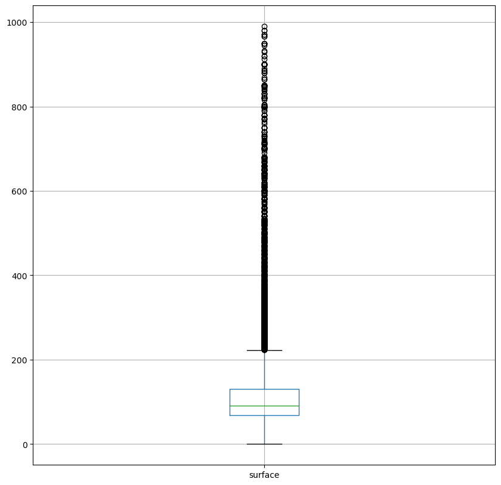

```python
# boxplot for surface
train_data.boxplot(['surface'], figsize = (10,10))
```

Lots of outliers here too.

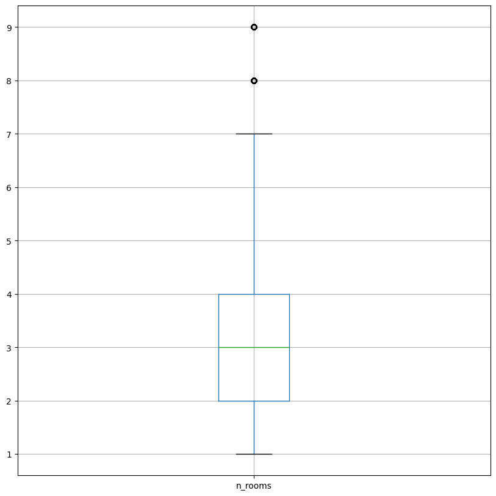

```python
# boxplot for n_rooms
train_data.boxplot(['n_rooms'], figsize = (10,10))
```

```
array([[<AxesSubplot:title={'center':'id'}>,
        <AxesSubplot:title={'center':'price'}>,
        <AxesSubplot:title={'center':'construction_year'}>,
        <AxesSubplot:title={'center':'latitude'}>],
       [<AxesSubplot:title={'center':'longitude'}>,
        <AxesSubplot:title={'center':'energy_efficiency'}>,
        <AxesSubplot:title={'center':'expenses'}>,
        <AxesSubplot:title={'center':'floor'}>],
       [<AxesSubplot:title={'center':'n_bathrooms'}>,
        <AxesSubplot:title={'center':'elevator'}>,
        <AxesSubplot:title={'center':'total_floors'}>,
        <AxesSubplot:title={'center':'n_rooms'}>],
       [<AxesSubplot:title={'center':'proximity_to_center'}>,
        <AxesSubplot:title={'center':'surface'}>, <AxesSubplot:>,
        <AxesSubplot:>]], dtype=object)
```

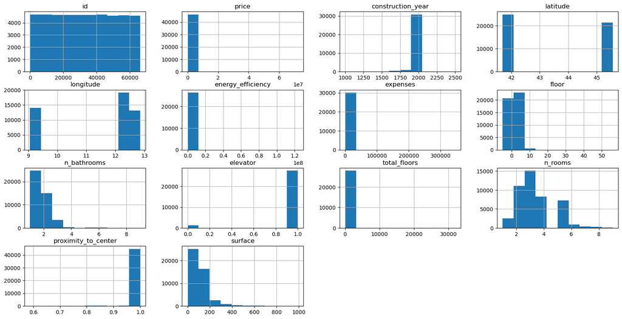

```python
train_data.hist(figsize=(20,10))
```

Taking a closer look at our target variable: price.

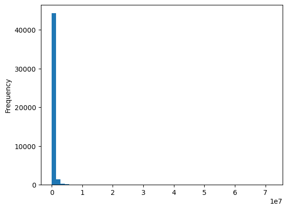

```python
train_data['price'].plot(kind='hist', bins = 50)
```

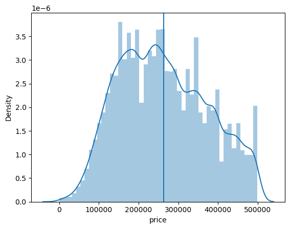

```python
# reducing the range
filtered_data = train_data[train_data['price'] <500000]
# filtered_data['price'].plot(kind='hist', bins = 50)
sns.distplot(filtered_data['price'])
plt.axvline(x=filtered_data['price'].mean())
```

```python
# categorical variable understanding through value counts
train_data['conditions'].value_counts()
```

```
Buono stato / Abitabile      21827
Ottimo / Ristrutturato       10533
Nuovo / Nuova costruzione     7045
Da ristrutturare              5678
Name: conditions, dtype: int64
```

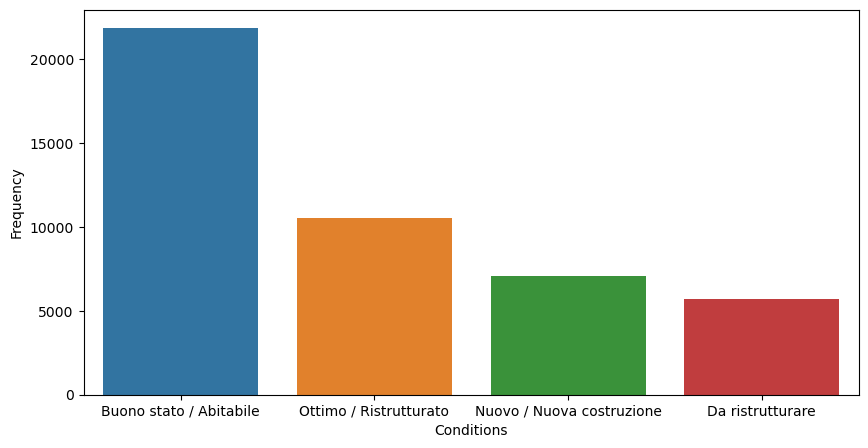

```python
cond_count = train_data['conditions'].value_counts()
plt.figure(figsize=(10,5))
sns.barplot(data=train_data, x=cond_count.index, y=cond_count.values)
plt.xlabel('Conditions')
plt.ylabel('Frequency')
```

**Feature Correlation**

```python
# drop the index column as it is irrelevant
# train_data.drop('id', axis=1, inplace=True)
```

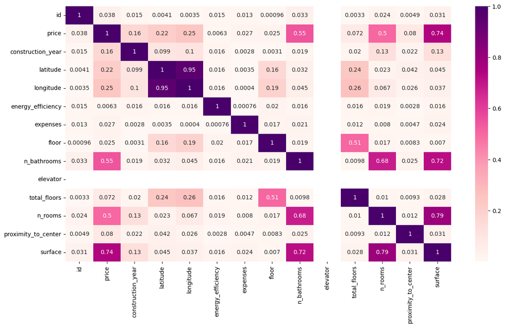

```python
corr = train_data.dropna().corr().abs()
plt.figure(figsize = (15,8))
sns.heatmap(corr, annot=True, cmap="RdPu")
```

# Preprocessing

**Filling in Missing Boolean Variables**

```python
# checking for missing data
train_data.isna().sum()
```

```
id                         0
price                      0
balcony                15443
conditions              1229
construction_year      13946
latitude                  13
longitude                 13
energy_efficiency      19903
expenses               16154
floor                   2031
garden                 31529
n_bathrooms             2416
elevator               17443
total_floors           18349
n_rooms                  353
proximity_to_center       13
surface                  443
dtype: int64
```

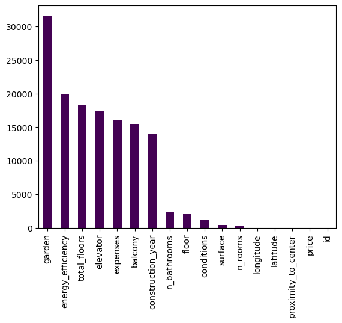

```python
# Visual plot of the above
train_data.isna().sum() \
    .sort_values(ascending = False) \
    .plot(kind='bar', cmap = 'viridis')
```

I would assume that location is pretty important for pricing, and hence, I will drop all points without coordinates.

```python
# checking missing points in the balcony feature
train_data['balcony'].value_counts()
# all missing values will be assumed to be False and converting to a {0,1} data point
train_data['balcony'] = train_data['balcony'].fillna(False)
train_data['balcony'] = train_data['balcony'].astype(int)
```

```python
# checking missing points in the elevator feature
train_data['elevator'].value_counts()
# all missing values will be assumed to be False and converting to a {0,1} data point
train_data['elevator'] = train_data['elevator'].fillna(False)
train_data['elevator'] = train_data['elevator'].astype(int)
```

```python
# checking missing points in the garden feature
train_data['garden'].value_counts()
# all missing values will be assumed to be False and converting to a {0,1} data point
train_data['garden'] = train_data['garden'].fillna(False)
train_data['garden'] = train_data['garden'].astype(int)
```

```python
# also fill in unknown conditions as unkown
train_data['conditions'] = train_data['conditions'].fillna('unknown')
```

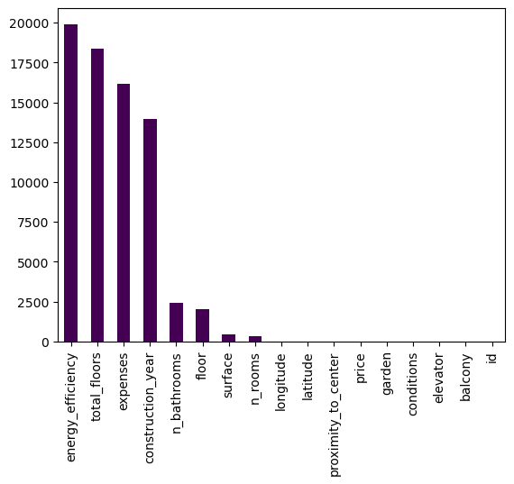

```python
train_data.isna().sum()
train_data.isna().sum() \
    .sort_values(ascending = False) \
    .plot(kind='bar', cmap = 'viridis')
```

```python
#dropping the ones without coordinates
train_data = train_data.dropna(subset=['latitude'])
```

**Dropping Duplicates**

```python
# checking for dupes
train_data.duplicated().sum()
```

```
0
```

```python
# checking for duplicates of latittude and longitude
train_data.duplicated(subset=['latitude', 'longitude']).sum()
```

```
9916
```

```python
# dropping these points
train_data.drop_duplicates(subset=['latitude', 'longitude'], inplace = True)
```

**Irrelevant Columns**

The energy efficiency column seems to have a very weak correlation to our target variable and many missing data points so I will drop it.

```python
# dropping energy efficiency
train_data.drop('energy_efficiency', axis=1, inplace=True)
```

```python
# drop expenses as well
train_data.drop('expenses', axis=1, inplace=True)
```

While construction year seems relevant to the price, most of this information will probably be encoded inthe conditions variable. As there is a lot of missing data, I will also drop this.

```python
train_data.drop('construction_year', axis=1, inplace=True)
```

```python
train_data.drop('total_floors', axis=1, inplace=True)
```

**Ecncoding the Conditions Variable** I will use one-hot encoding to handle the conditions variable to allow it to be used as a numerical input.

```python
train_data = pd.get_dummies(train_data, columns=['conditions'])
```

**Coordinates to Cities**

```python
import reverse_geocoder as rg

results = rg.search(list(zip(train_data['latitude'], train_data['longitude'])))
cities = [result['admin2'] for result in results]

train_data['city'] = cities
train_data.head()
```

|  | id | price | balcony | latitude | longitude | floor | garden | n_bathrooms | elevator | n_rooms | proximity_to_center | surface | conditions_Buono stato / Abitabile | conditions_Da ristrutturare | conditions_Nuovo / Nuova costruzione | conditions_Ottimo / Ristrutturato | conditions_unknown | city |
| --- | --- | --- | --- | --- | --- | --- | --- | --- | --- | --- | --- | --- | --- | --- | --- | --- | --- | --- |
| 0 | 10461 | 60000 | 1 | 41.901300 | 12.700000 | 2.0 | 0 | 1.0 | 0 | 1.0 | 1.00000 | 35.0 | 1 | 0 | 0 | 0 | 0 | Citta metropolitana di Roma Capitale |
| 1 | 51304 | 900000 | 0 | 41.907017 | 12.481311 | 3.0 | 0 | 1.0 | 1 | 3.0 | 1.00000 | 131.0 | 1 | 0 | 0 | 0 | 0 |  |
| 2 | 33032 | 33000 | 0 | 41.976500 | 12.440500 | 4.0 | 0 | 1.0 | 0 | 1.0 | 1.00000 | 16.0 | 1 | 0 | 0 | 0 | 0 |  |
| 3 | 62281 | 166000 | 0 | 45.484800 | 12.198200 | 1.0 | 1 | 1.0 | 0 | 2.0 | 0.99205 | 100.0 | 0 | 0 | 0 | 1 | 0 | Provincia di Venezia |
| 4 | 45681 | 410000 | 1 | 45.424480 | 12.328622 | 3.0 | 0 | 2.0 | 1 | 3.0 | 1.00000 | 90.0 | 1 | 0 | 0 | 0 | 0 | Provincia di Venezia |

Now i want to use one-hot encoding as this is a categorical variable.

```python
train_data = pd.get_dummies(train_data, columns=['city'])
```

```python
train_data.isna().sum()
```

```
id                                              0
price                                           0
balcony                                         0
latitude                                        0
longitude                                       0
floor                                        1721
garden                                          0
n_bathrooms                                  1943
elevator                                        0
n_rooms                                       281
proximity_to_center                             0
surface                                        93
conditions_Buono stato / Abitabile              0
conditions_Da ristrutturare                     0
conditions_Nuovo / Nuova costruzione            0
conditions_Ottimo / Ristrutturato               0
conditions_unknown                              0
city_                                           0
city_Citta metropolitana di Milano              0
city_Citta metropolitana di Roma Capitale       0
city_Provincia di Treviso                       0
city_Provincia di Venezia                       0
dtype: int64
```

```python
train_data.drop('latitude', axis=1, inplace=True)
train_data.drop('longitude', axis=1, inplace=True)
```

# Train test split

```python
from sklearn.model_selection import train_test_split
train_set, test_set = train_test_split(train_data, test_size = 0.2, random_state=42)
```

```python
train_set.shape
```

```
(29106, 20)
```

# Filling in the Remaing Missing Data

**Missing Values** Using the simple imputer from sklearn, I will imput the missing values.

```python
train_set.isna().sum()
```

```
id                                              0
price                                           0
balcony                                         0
floor                                        1346
garden                                          0
n_bathrooms                                  1538
elevator                                        0
n_rooms                                       211
proximity_to_center                             0
surface                                        75
conditions_Buono stato / Abitabile              0
conditions_Da ristrutturare                     0
conditions_Nuovo / Nuova costruzione            0
conditions_Ottimo / Ristrutturato               0
conditions_unknown                              0
city_                                           0
city_Citta metropolitana di Milano              0
city_Citta metropolitana di Roma Capitale       0
city_Provincia di Treviso                       0
city_Provincia di Venezia                       0
dtype: int64
```

```python
from sklearn.impute import SimpleImputer
my_imputer = SimpleImputer(strategy='median')
train_set[['price', 'balcony', 'floor',
       'garden', 'n_bathrooms', 'elevator', 'n_rooms',
       'proximity_to_center', 'surface']] = my_imputer.fit_transform(train_set[['price', 'balcony', 'floor',
       'garden', 'n_bathrooms', 'elevator', 'n_rooms',
       'proximity_to_center', 'surface']])
```

```python
from sklearn.impute import SimpleImputer
my_imputer = SimpleImputer(strategy='median')
test_set[['price', 'balcony', 'floor',
       'garden', 'n_bathrooms', 'elevator', 'n_rooms',
       'proximity_to_center', 'surface']] = my_imputer.fit_transform(test_set[['price', 'balcony', 'floor',
       'garden', 'n_bathrooms', 'elevator', 'n_rooms',
       'proximity_to_center', 'surface']])
```

```python
# more complex imputer

# cols_w_missing = (col for col in train_set.columns
#                                  if train_set[col].isnull().any())

# for col in cols_w_missing:
#     train_set[col + '_was_missing'] = train_set[col].isnull()

# my_imputer = SimpleImputer(strategy='median')
# train_set[['price', 'balcony', 'latitude', 'longitude', 'floor',
#        'garden', 'n_bathrooms', 'elevator', 'total_floors', 'n_rooms',
#        'proximity_to_center', 'surface']] = my_imputer.fit_transform(train_set[['price', 'balcony', 'latitude', 'longitude', 'floor',
#        'garden', 'n_bathrooms', 'elevator', 'total_floors', 'n_rooms',
#        'proximity_to_center', 'surface']])
```

```python
train_set.isna().sum()
```

```
id                                           0
price                                        0
balcony                                      0
floor                                        0
garden                                       0
n_bathrooms                                  0
elevator                                     0
n_rooms                                      0
proximity_to_center                          0
surface                                      0
conditions_Buono stato / Abitabile           0
conditions_Da ristrutturare                  0
conditions_Nuovo / Nuova costruzione         0
conditions_Ottimo / Ristrutturato            0
conditions_unknown                           0
city_                                        0
city_Citta metropolitana di Milano           0
city_Citta metropolitana di Roma Capitale    0
city_Provincia di Treviso                    0
city_Provincia di Venezia                    0
dtype: int64
```

# Outlier Detection

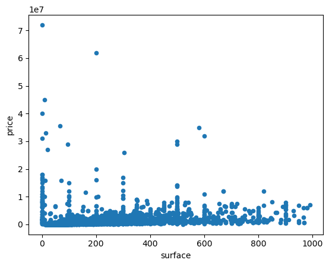

```python
train_set.plot(kind="scatter", x='surface', y='price')
```

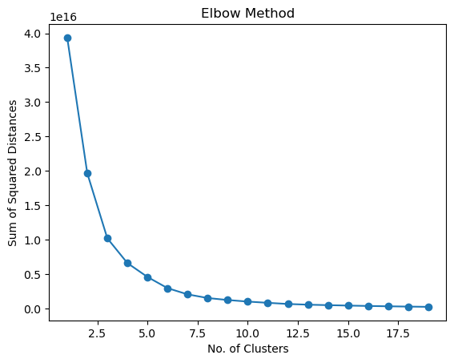

```python
from sklearn.cluster import KMeans
features = train_set[['price', 'surface']]

ssd=[]

for k in range(1, 20):
    kmeans = KMeans(n_clusters=k, random_state=42)
    kmeans.fit(features)
    ssd.append(kmeans.inertia_)

plt.plot(range(1,20), ssd, marker = 'o')
plt.title("Elbow Method")
plt.xlabel("No. of Clusters")
plt.ylabel("Sum of Squared Distances")
plt.show()
```

```python
# np array of desired variables
features = train_set[['price', 'surface']].values
kmeans = KMeans(n_clusters=15, random_state=42).fit(features)
dists = kmeans.transform(features)
min_dists = np.min(dists, axis = 1)

threshold = np.percentile(min_dists, 97.5)
outliers = train_set[min_dists > threshold]

train_set = train_set.drop(outliers.index)
```

```python
train_set.shape
```

```
(28379, 20)
```

# Scaling

```python
from sklearn.preprocessing import StandardScaler

global scaler
scaler = StandardScaler()
train_set['surface'] = scaler.fit_transform(train_set[['surface']])
test_set['surface'] = scaler.transform(test_set[['surface']])
```

# Modelling

```python
from sklearn.model_selection import train_test_split
y_train = train_set['price']
train_set.drop('price', axis=1, inplace=True)
train_set.drop('id', axis=1, inplace=True)

y_test = test_set['price']
test_set.drop('price', axis=1, inplace=True)
test_set.drop('id', axis=1, inplace=True)
```

```python
# X_train, X_test, y_train, y_test = train_test_split(train_data, y, test_size = 0.2, random_state=42)
```

```python
# applying the same transformations to the test data
def transforms(dataframe):
    # filling missing data points for bool features
    dataframe['balcony'] = dataframe['balcony'].fillna(False)
    dataframe['balcony'] = dataframe['balcony'].astype(int)

    dataframe['elevator'] = dataframe['elevator'].fillna(False)
    dataframe['elevator'] = dataframe['elevator'].astype(int)

    dataframe['garden'] = dataframe['garden'].fillna(False)
    dataframe['garden'] = dataframe['garden'].astype(int)

    # filling in missing conditions data
    dataframe['conditions'] = dataframe['conditions'].fillna('unknown')

    # drop energy efficiency, expenses, construction year, id
    global index
    index = dataframe['id']
    dataframe.drop('id', axis=1, inplace=True)
    dataframe.drop('energy_efficiency', axis=1, inplace=True)
    dataframe.drop('expenses', axis=1, inplace=True)
    dataframe.drop('construction_year', axis=1, inplace=True)
    dataframe.drop('total_floors', axis=1, inplace=True)

    #filling in missing values
#     dataframe['latitude'] = dataframe['latitude'].fillna(0)
#     dataframe['longitude'] = dataframe['longitude'].fillna(0)
    dataframe['proximity_to_center'] = dataframe['proximity_to_center'].fillna(0)

    my_imputer = SimpleImputer(strategy='median')
    dataframe[['balcony', 'latitude', 'longitude', 'floor',
       'garden', 'n_bathrooms', 'elevator', 'n_rooms',
       'proximity_to_center', 'surface']] = my_imputer.fit_transform(dataframe[['balcony', 'latitude', 'longitude', 'floor',
       'garden', 'n_bathrooms', 'elevator', 'n_rooms',
       'proximity_to_center', 'surface']])

    #one-hot encoding condiitons
    dataframe = pd.get_dummies(dataframe, columns = ['conditions'])

    #Cities + one-hot encoding
    results = rg.search(list(zip(dataframe['latitude'], dataframe['longitude'])))
    cities = [result['admin2'] for result in results]

    dataframe['city'] = cities
    dataframe = pd.get_dummies(dataframe, columns = ['city'])

    dataframe.drop('latitude', axis=1, inplace=True)
    dataframe.drop('longitude', axis=1, inplace=True)

    dataframe['surface'] = scaler.transform(dataframe[['surface']])

    return dataframe
```

```python
# regression models
from sklearn.svm import SVR
from xgboost import XGBRegressor
from sklearn.linear_model import Ridge
from sklearn.linear_model import Lasso
from sklearn.linear_model import SGDRegressor
from sklearn.linear_model import LinearRegression
from sklearn.ensemble import RandomForestRegressor

# Evaluation function
from sklearn.metrics import mean_squared_error
```

```python
models ={'SVR': SVR(), 'XGBRegressor':XGBRegressor(),'Ridge': Ridge(), 'SGDRegressor':SGDRegressor(), 'LinearRegression':LinearRegression(),'RandomForestRegressor':RandomForestRegressor()}
model_results = []
model_names = []
for name, model in models.items():
    a = model.fit(train_set, y_train)
    predicted = a.predict(test_set)
    score = mean_squared_error(y_test, predicted)
    model_results.append(score)
    model_names.append(name)

    train_results = pd.DataFrame([model_names,model_results])
    train_results = train_results.transpose()
    train_results = train_results.rename(columns={0:'Model', 1:'MSE'}).sort_values(by='MSE', ascending=False)
print(train_results)

# Adapted from ("https://www.kaggle.com/code/heyrobin/house-price-prediction-beginner-s-notebook")
```

```
                   Model                   MSE
0                    SVR  1106032071541.879639
2                  Ridge   892137515795.328735
4       LinearRegression   892123630298.925293
3           SGDRegressor   888784124615.185669
5  RandomForestRegressor   800459004506.975952
1           XGBRegressor   768158531273.859009
```

```python
from sklearn.model_selection import GridSearchCV

XGB = XGBRegressor()
param_grid = {'n_estimators' : [80, 100, 120],
              'max_depth' : [1, 2, 3, 4],
              'learning_rate' : [0.05, 0.1, 0.2]}

grid_search = GridSearchCV(XGB, param_grid, cv=5, scoring='neg_mean_squared_error')
grid_search.fit(train_set, y_train)

print("Best Hyperparameters: ", grid_search.best_params_)
print("Test set score: ", grid_search.score(test_set, y_test))
```

```
Best Hyperparameters:  {'learning_rate': 0.2, 'max_depth': 3, 'n_estimators': 120}
Test set score:  -752170926710.7035
```

```python
global best_params
best_params = grid_search.best_params_
print(best_params)
```

```
{'learning_rate': 0.2, 'max_depth': 3, 'n_estimators': 120}
```

# Predicting

```python
# loading in test data
test_file_path = '../input/challenge/test_updated.csv'
test_data = pd.read_csv(test_file_path)
```

```python
global test_data
test_data = transforms(test_data)
```

```python
model = XGBRegressor(random_state=42, **best_params).fit(train_set, y_train)
predicted = model.predict(test_data)
```

```python
df = pd.DataFrame({'id': index, 'price': predicted})
df.to_csv('submissiontest.csv', index = False)
```